# SimpleLSTMBasedTimeSeriesModel

## Dataset:

The dataset I used here is from Stock price data of the fifty stocks in NIFTY-50 index from [NSE India](https://www.kaggle.com/rohanrao/nifty50-stock-market-data?select=KOTAKBANK.csv). You can download and can start.

```python
import numpy as np
import pandas as pd
import matplotlib.pyplot as plt
```

```python
kota=pd.read_csv('/_Give_your_data_path_/datasets_423609_1296539_KOTAKBANK.csv')
```

```python
data=kota.copy()                # Copying into data variabe.
```

### Let see our top five values.

```python
data.head()
```

|  | Date | Symbol | Series | Prev Close | Open | High | Low | Last | Close | VWAP | Volume | Turnover | Trades | Deliverable Volume | %Deliverble |
| --- | --- | --- | --- | --- | --- | --- | --- | --- | --- | --- | --- | --- | --- | --- | --- |
| 0 | 2000-01-03 | KOTAKMAH | EQ | 212.35 | 220.0 | 229.35 | 220.00 | 229.35 | 229.35 | 229.13 | 7086 | 1.623640e+11 | NaN | NaN | NaN |
| 1 | 2000-01-04 | KOTAKMAH | EQ | 229.35 | 247.7 | 247.70 | 225.25 | 247.70 | 246.95 | 244.12 | 73681 | 1.798729e+12 | NaN | NaN | NaN |
| 2 | 2000-01-05 | KOTAKMAH | EQ | 246.95 | 229.0 | 240.00 | 227.20 | 228.00 | 228.40 | 233.75 | 105799 | 2.473093e+12 | NaN | NaN | NaN |
| 3 | 2000-01-06 | KOTAKMAH | EQ | 228.40 | 235.1 | 239.00 | 217.00 | 224.95 | 225.90 | 226.84 | 40202 | 9.119546e+11 | NaN | NaN | NaN |
| 4 | 2000-01-07 | KOTAKMAH | EQ | 225.90 | 213.0 | 219.00 | 207.85 | 207.85 | 208.85 | 209.94 | 24463 | 5.135747e+11 | NaN | NaN | NaN |

### Let see our bottom five values.

```python
data.tail()
```

|  | Date | Symbol | Series | Prev Close | Open | High | Low | Last | Close | VWAP | Volume | Turnover | Trades | Deliverable Volume | %Deliverble |
| --- | --- | --- | --- | --- | --- | --- | --- | --- | --- | --- | --- | --- | --- | --- | --- |
| 4771 | 2020-06-24 | KOTAKBANK | EQ | 1389.90 | 1392.0 | 1398.00 | 1336.95 | 1346.00 | 1343.90 | 1373.54 | 5332634 | 7.324580e+14 | 181894.0 | 2127124.0 | 0.3989 |
| 4772 | 2020-06-25 | KOTAKBANK | EQ | 1343.90 | 1337.0 | 1389.75 | 1325.00 | 1367.15 | 1381.70 | 1366.39 | 9985038 | 1.364347e+15 | 243119.0 | 4640972.0 | 0.4648 |
| 4773 | 2020-06-26 | KOTAKBANK | EQ | 1381.70 | 1380.0 | 1382.95 | 1326.95 | 1349.20 | 1340.10 | 1341.68 | 6694715 | 8.982180e+14 | 206470.0 | 2363994.0 | 0.3531 |
| 4774 | 2020-06-29 | KOTAKBANK | EQ | 1340.10 | 1336.1 | 1366.90 | 1313.00 | 1359.00 | 1355.65 | 1333.26 | 3819683 | 5.092647e+14 | 117930.0 | 1010626.0 | 0.2646 |
| 4775 | 2020-06-30 | KOTAKBANK | EQ | 1355.65 | 1364.9 | 1372.90 | 1345.05 | 1352.30 | 1360.45 | 1360.08 | 4783169 | 6.505497e+14 | 142352.0 | 1723103.0 | 0.3602 |

As we can see there are lots of columns or features of but for a moment we will see only only one variale called **'Close'**, which is our feature and try to make a model.

### Let see the size of the dataset.

```python
data.shape
```

```
(4776, 15)
```

### This our features.

```python
data.columns
```

```
Index(['Date', 'Symbol', 'Series', 'Prev Close', 'Open', 'High', 'Low', 'Last',
       'Close', 'VWAP', 'Volume', 'Turnover', 'Trades', 'Deliverable Volume',
       '%Deliverble'],
      dtype='object')
```

### Converting dataframe value into array.

```python
data=data['Close'].values
```

```python
data
```

```
array([ 229.35,  246.95,  228.4 , ..., 1340.1 , 1355.65, 1360.45])
```

### Let's plot.

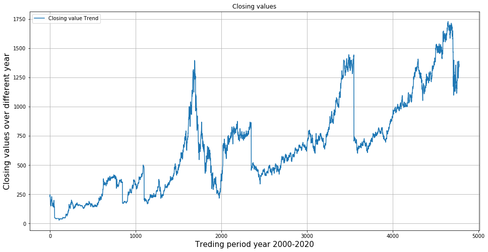

```python
plt.figure(figsize=(16,8))
plt.plot(kota.index,kota['Close'])
plt.title('Closing values')
plt.xlabel('Treding period year 2000-2020',fontsize=15)
plt.ylabel('Closing values over different year',fontsize=16)
plt.legend(['Closing value Trend'])
plt.grid()
plt.show()
```

### We will ues MinMaxScaler to normalize it.

```python
from sklearn.preprocessing import MinMaxScaler
from sklearn.metrics import mean_squared_error

scalar=MinMaxScaler(feature_range=(0,1))
dataset=scalar.fit_transform(data.reshape(data.shape[0],1))
dataset
```

```
array([[0.11869933],
       [0.12903889],
       [0.11814123],
       ...,
       [0.77123722],
       [0.78037246],
       [0.78319234]])
```

### Let see our dataset size.

```python
dataset.shape
```

```
(4776, 1)
```

```python
dataset=dataset.reshape(data.shape[0])
```

### This is our function which will split the data into target and features.

```python
def split_set(data,time_steps):
    split_X=[]
    split_y=[]
    split=[[data[j+i] for j in range(time_steps)] for i in range(len(data)-time_steps)]
    split_X=split

    for i in range(len(data)-time_steps):
        split_y.append([data[i+time_steps]])
    return np.array(split_X),np.array(split_y)
```

### So here our timeP_steps=1. We can also change it by our convience.

Here we are spliting the dataset.

```python
time_steps=1
split_X,split_y=split_set(dataset,time_steps)
split_X
```

```
array([[0.11869933],
       [0.12903889],
       [0.11814123],
       ...,
       [0.79567618],
       [0.77123722],
       [0.78037246]])
```

### Here we splitting the dataset into train and test. 80 percent for train and 20 percent for test dataset.

```python
train_size=int(len(split_X)*0.80)
test_size=len(split_X)-train_size

print('Train-size=',train_size)
print('Test-size=',test_size)
```

```
Train-size= 3820
Test-size= 955
```

```python
train_X=split_X[0:train_size,]
train_y=split_y[0:train_size,]


test_X=split_X[train_size:len(dataset),]
test_y=split_y[train_size:len(dataset),]
```

### Let's see our samples shape

```python
print(test_X.shape)
print(test_y.shape)
```

```
(955, 1)
(955, 1)
```

### Reshaping the train_X and test_X to feed into the model and predict.

```python
train_X=train_X.reshape(train_X.shape[0],time_steps,1)
test_X=test_X.reshape(test_X.shape[0],time_steps,1)
```

```python
print(train_X.shape)
```

```
(3820, 1, 1)
```

### This is our functional keras model

```python
import tensorflow as tf
from tensorflow.keras.layers import Dense,LSTM,Input
from tensorflow.keras.models import Model

data_input=Input(shape=(time_steps,train_X.shape[2]))
lstm1=LSTM(50,return_sequences=True)(data_input)
lstm2=LSTM(30)(lstm1)
dense_output=Dense(20)(lstm2)
output=Dense(1)(dense_output)
model=Model(data_input,output)
model.summary()
```

```
WARNING:tensorflow:From /home/kapil/anaconda3/lib/python3.7/site-packages/tensorflow/python/ops/resource_variable_ops.py:435: colocate_with (from tensorflow.python.framework.ops) is deprecated and will be removed in a future version.
Instructions for updating:
Colocations handled automatically by placer.
_________________________________________________________________
Layer (type)                 Output Shape              Param #
=================================================================
input_1 (InputLayer)         (None, 1, 1)              0
_________________________________________________________________
lstm (LSTM)                  (None, 1, 50)             10400
_________________________________________________________________
lstm_1 (LSTM)                (None, 30)                9720
_________________________________________________________________
dense (Dense)                (None, 20)                620
_________________________________________________________________
dense_1 (Dense)              (None, 1)                 21
=================================================================
Total params: 20,761
Trainable params: 20,761
Non-trainable params: 0
_________________________________________________________________
```

### Lets fit the training sample into model

```python
model.compile(loss='mse', optimizer='adam')
model.fit(train_X,train_y,epochs=10,batch_size=10)
```

[output not shown]

```
<tensorflow.python.keras.callbacks.History at 0x7ff8f8d24910>
```

### So let's see our model prediction on test_X

```python
prediction=model.predict(test_X)
prediction
```

[output not shown]

[output cut: 900 more lines]

```
       [0.75076956],
       [0.7670381 ],
       [0.747611  ],
       [0.7366494 ],
       [0.7187014 ],
       [0.73490834],
       [0.7157361 ],
       [0.75030607],
       [0.74981356],
       [0.7803901 ],
       [0.8003232 ],
       [0.7737743 ],
       [0.79559636],
       [0.77157766],
       [0.7805634 ]], dtype=float32)
```

### Note that we want our original data so we will inverse_transform our prevoius transformed dataset.

```python
fit_data=scalar.fit(data.reshape(data.shape[0],1))
#fit_data.inverse_transform(np.array(prediction))
```

```python
original_target_feature=fit_data.inverse_transform(split_y)   #from split_y
original_prediction_test=fit_data.inverse_transform(prediction)
```

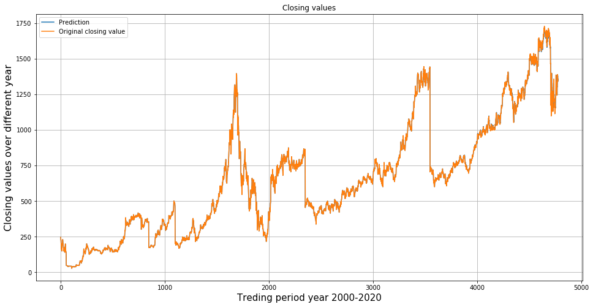

```python
train=original_target_feature.reshape(split_y.shape[0]).copy()
train[train_size:len(split_y),]=original_prediction_test.reshape(prediction.shape[0])

plt.figure(figsize=(16,8))
plt.plot(train)
plt.plot(original_target_feature.reshape(split_y.shape[0]))
plt.title('Closing values')
plt.xlabel('Treding period year 2000-2020',fontsize=15)
plt.ylabel('Closing values over different year',fontsize=16)
plt.grid()
plt.legend(['Prediction','Original closing value'])
plt.show()
```

As we can seee it seems to be good prediction.That's great. Now we zoom it on test dataset part. Which will give us better idea and visulization.

### Zooming on test_data

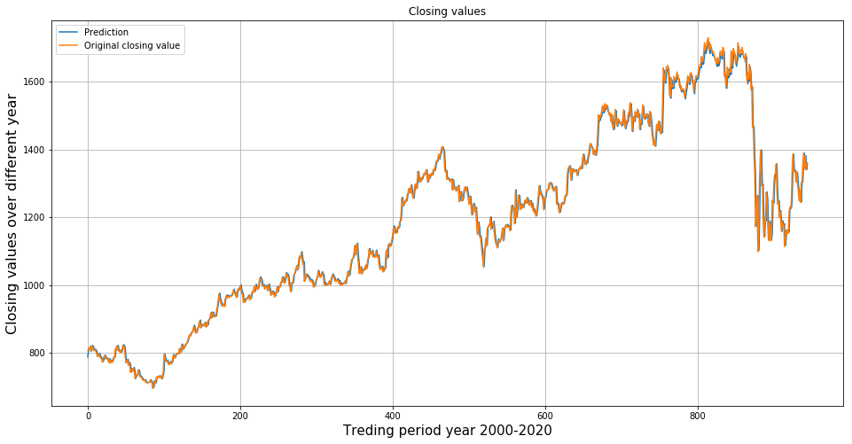

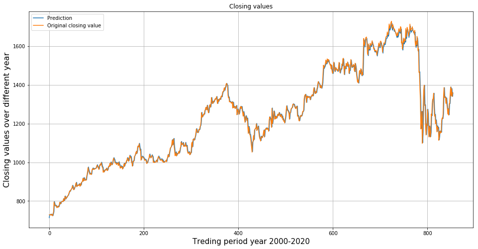

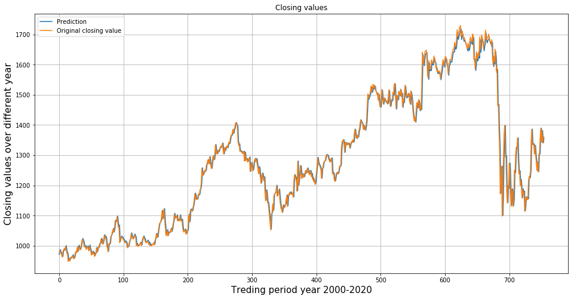

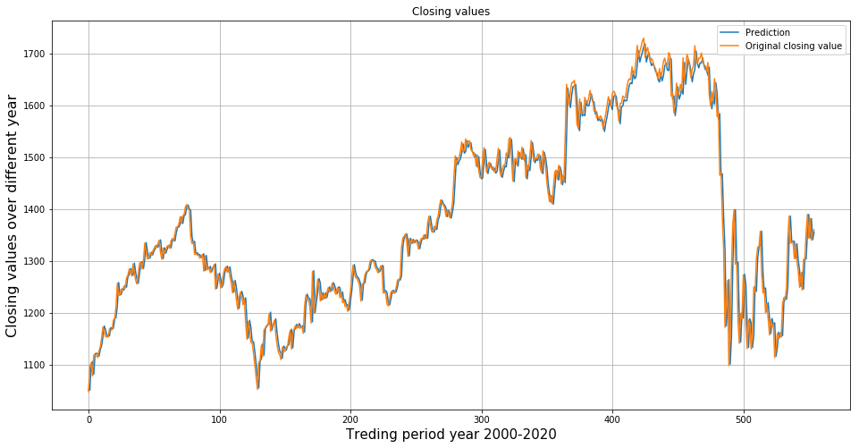

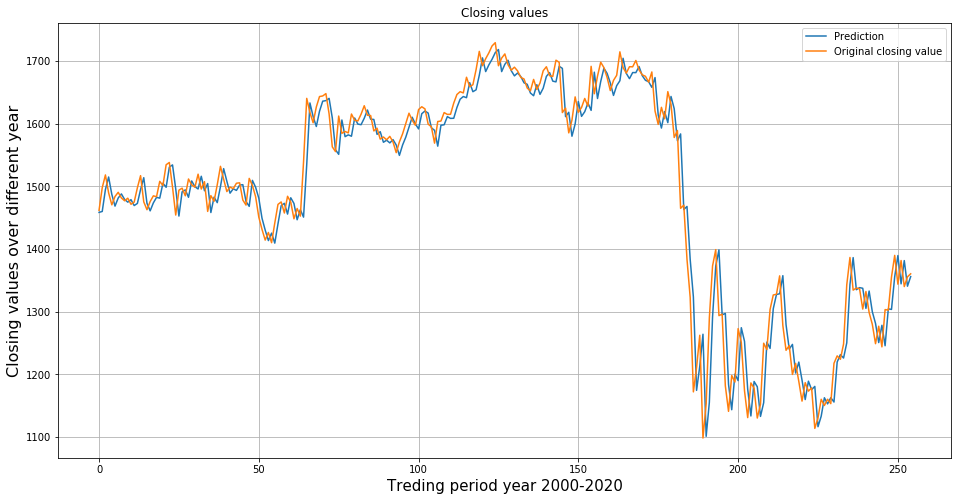

```python
for i in [10,100,200,400,700]:
    plt.figure(figsize=(16,8))
    plt.plot(train[train_size+i:len(split_y)])
    plt.plot(original_target_feature.reshape(split_y.shape[0])[train_size+i:len(split_y)])
    plt.title('Closing values')
    plt.xlabel('Treding period year 2000-2020',fontsize=15)
    plt.ylabel('Closing values over different year',fontsize=16)
    plt.grid()
    plt.legend(['Prediction','Original closing value'])
    plt.show()
```